# 2019 Carp Networks

Lauren White

8/7/2019

## Load libraries, load data, clean data

In `"Parley_Halsteads_PIT.csv"`:

- there are still several `PIT` IDs that are only five digits (mostly starting with “38”)
- `Full.PIT` has been saved in scientific notation in the csv file, so last few digits are lost, even if I try to read in that column as characters

Possibly because of the reasons above (or different species or prior captures?), PIT IDs of fish at lotus site do not match any of the recent captures.

Unique visitors:

```r
library(dplyr)
library(stringr)
library(lubridate)
library(Matrix)
library(igraph)
library(bipartite)
library(data.table)
library(ggplot2)
library(gganimate)

#Capture data: refromat capture date as POISXct; retain PIT#, species, and capture date
pit_capture <-read.csv("Parley_Halsteads_PIT.csv", stringsAsFactors = FALSE, colClasses = "character")
pit_capture<- select(pit_capture, c(Lake, PIT, Length, Sex))
pit_capture$PIT<-as.character(pit_capture$PIT)
head(pit_capture)
```

```
##     Lake    PIT Length Sex
## 1 Parley 497897    560   M
## 2 Parley 497857    720   F
## 3 Parley 497819    585   M
## 4 Parley 497887    690   M
## 5 Parley 497803    640   U
## 6 Parley 497862    740   U
```

```r
#Boatramp site
# boatramp<-read.csv("Boatramp_Progress.csv", stringsAsFactors = FALSE)
boatramp2<-read.table("Boat_ramp_inprogress.log", header=FALSE, fill=TRUE,col.names=c("D", "Date", "Time", "Time2", "HA", "PIT", "Antenna", "Col1","Col2"), na.strings=c("", "NA"))
boatramp2<-select(boatramp2, c(Date, Time, PIT, Antenna))

boatramp2$DATETIME<- as.POSIXct(paste(boatramp2$Date,boatramp2$Time), format='%Y-%m-%d %H:%M:%S', tz="CDT") #Reformat as POSIXct
boatramp2<-boatramp2[-which(is.na(boatramp2$DATETIME)),] #remove NA values
boatramp2$PIT<-as.character(boatramp2$PIT) #toString(boatramp2$PIT)
boatramp2$PIT<-str_sub(boatramp2$PIT, 11, 16)
boatramp2$PIT[boatramp2$PIT==""] <- NA
boatramp2<-boatramp2[-which(is.na(boatramp2$PIT)),]
boatramp2$Site<-"B"

merged_br<- merge(boatramp2, pit_capture,  by="PIT")
head(merged_br)
```

```
##      PIT       Date        Time Antenna            DATETIME Site   Lake
## 1 497600 2019-07-31 20:39:49.34      A1 2019-07-31 20:39:49    B Parley
## 2 497600 2019-08-03 03:55:11.56      A3 2019-08-03 03:55:11    B Parley
## 3 497600 2019-08-03 16:08:18.25      A2 2019-08-03 16:08:18    B Parley
## 4 497600 2019-07-31 19:24:12.15      A1 2019-07-31 19:24:12    B Parley
## 5 497600 2019-08-05 12:13:08.82      A1 2019-08-05 12:13:08    B Parley
## 6 497600 2019-07-31 20:39:50.55      A1 2019-07-31 20:39:50    B Parley
##   Length Sex
## 1    615   F
## 2    615   F
## 3    615   F
## 4    615   F
## 5    615   F
## 6    615   F
```

```r
#Lotus site
lotus<-read.table("lotus_inprogress.log", header=FALSE, fill=TRUE,col.names=c("D", "Date", "Time", "Time2", "HA", "PIT", "Antenna", "Col1","Col2"), na.strings=c("", "NA"))
lotus<-select(lotus, c(Date, Time, PIT, Antenna))

lotus$DATETIME<- as.POSIXct(paste(lotus$Date,lotus$Time), format='%Y-%m-%d %H:%M:%S', tz="CDT") #Reformat as POSIXct
lotus<-lotus[-which(is.na(lotus$DATETIME)),] #remove NA values
lotus$PIT<-as.character(lotus$PIT) #toString(lotus$PIT)
lotus$PIT<-str_sub(lotus$PIT, 11, 16)
lotus$PIT[lotus$PIT==""] <- NA
lotus<-lotus[-which(is.na(lotus$PIT)),]
lotus$Site<-"L"
unique(lotus$PIT)
```

```
## [1] "567225" "567072" "497581" "974777" "567357"
```

```r
(length(unique(lotus$PIT))) #how many uniquely tagged carp?
```

```
## [1] 5
```

```r
isTRUE(pit_capture$PIT %in% lotus$PIT)
```

```
## [1] FALSE
```

```r
# merged_lotus<- merge(lotus, pit_capture,  by="PIT")
# merged_lotus$Site<-"L"
# head(merged_lotus)

#Crown site
crown<-read.table("crown_inprgoress.log", header=FALSE, fill=TRUE,col.names=c("D", "Date", "Time", "Time2", "HA", "PIT", "Antenna", "Col1","Col2"), na.strings=c("", "NA"))
crown<-select(crown, c(Date, Time, PIT, Antenna))

crown<-crown[-which(is.na(crown$Antenna)),]
crown$DATETIME<- as.POSIXct(paste(as.character(crown$Date),as.character(crown$Time)), format='%Y-%m-%d %H:%M:%S', tz="CDT") #Reformat as POSIXct
# crown<-crown[-which(is.na(crown$DATETIME)),] #remove NA values
crown$PIT<-as.character(crown$PIT) #toString(crown$PIT)
crown$PIT<-str_sub(crown$PIT, 11, 16)
crown$PIT[crown$PIT==""] <- NA
crown<-crown[-which(is.na(crown$PIT)),]
crown$Site<-"C"

merged_crown<- merge(crown, pit_capture,  by="PIT")
head(merged_crown)
```

```
##      PIT       Date        Time Antenna            DATETIME Site   Lake
## 1 497622 2019-08-03 17:32:11.31      A2 2019-08-03 17:32:11    C Parley
## 2 497622 2019-08-02 15:54:20.82      A1 2019-08-02 15:54:20    C Parley
## 3 497622 2019-08-06 16:24:02.71      A1 2019-08-06 16:24:02    C Parley
## 4 497622 2019-08-03 17:32:12.21      A2 2019-08-03 17:32:12    C Parley
## 5 497622 2019-08-06 16:24:06.65      A1 2019-08-06 16:24:06    C Parley
## 6 497622 2019-08-02 17:11:06.78      A2 2019-08-02 17:11:06    C Parley
##   Length Sex
## 1    376   M
## 2    376   M
## 3    376   M
## 4    376   M
## 5    376   M
## 6    376   M
```

```r
(length(unique(merged_br$PIT))) #how many uniquely tagged carp?
```

```
## [1] 46
```

```r
(length(unique(merged_crown$PIT))) #how many uniquely tagged carp?
```

```
## [1] 48
```

## Boat ramp site unique visitors and antennae usage

Identify number of unique visitors per day and whether carp are being detected by multiple antennae at given site.

- Detection numbers begin increasing on sampling day seven (start of baiting?)
- Most fish are detected by three readers. A few are detected by all four readers (A1-A4)
- For a given sampling day, most fish are not detected by 3+ readers
- A4 is the least visited reader so far
- Lost the ability to detect PIT tags on boat ramp antennas from ~ noon on 8/6/19 to morning of 8/7/19

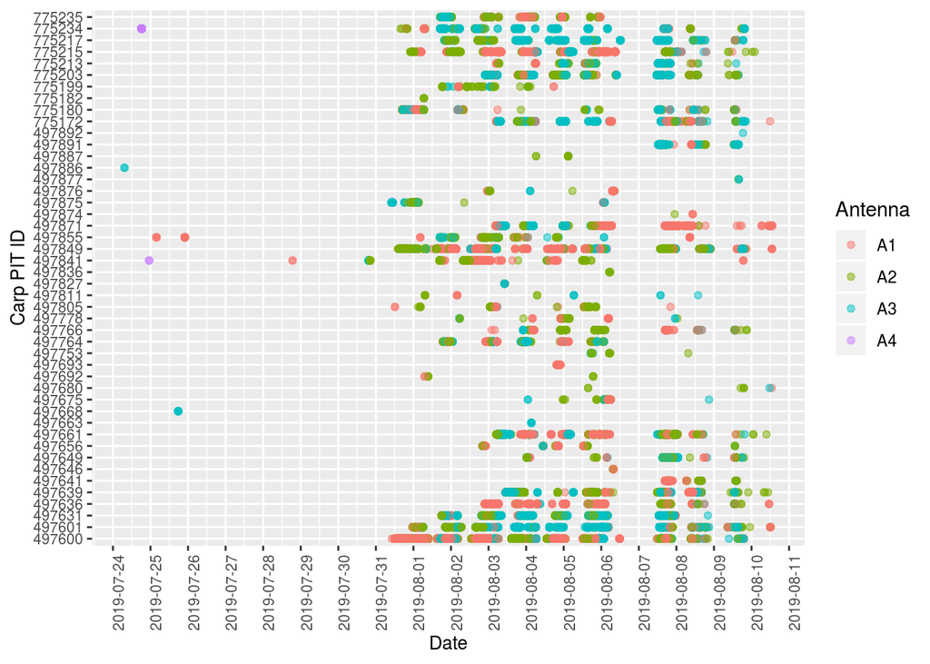

```r
ggplot(data=merged_br, aes(DATETIME, as.factor(PIT), colour=Antenna)) +
  geom_point(alpha=0.5) +
  scale_x_datetime(date_breaks="1 day")+
  xlab("Date")+
  ylab("Carp PIT ID")+
  theme(axis.text.x=element_text(angle=90), axis.text=element_text(size=8), axis.title = element_text(size=10))
```

```r
dates<-unique(merged_br$DATETIME) #how many dates of observation in dataset?
(min_date<-min(dates))
```

```
## [1] "2019-07-24 07:22:41 CDT"
```

```r
(max_date<-max(dates))
```

```
## [1] "2019-08-10 13:17:36 CDT"
```

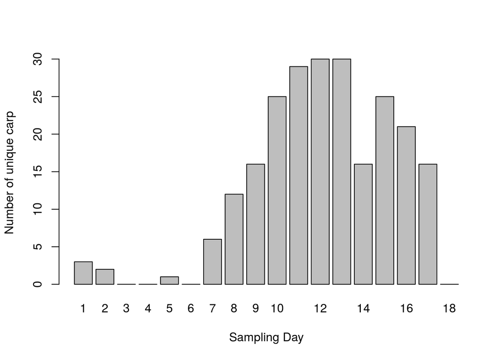

```r
start_date<-as.POSIXct("2019-07-24 12:00:00 CDT")
end_date<-as.POSIXct("2019-08-11 12:00:00 CDT")

num_days<-as.numeric(end_date-start_date)
sampling_df <-data.frame(day=1:num_days, uniqueID=rep(NA, num_days))
degree_list<-NULL

for(i in 1:num_days){
  sub_combined<-merged_br %>% filter(DATETIME >= as.POSIXct(start_date+ (i-1)*86400, tz="CDT") & DATETIME <= as.POSIXct(start_date + i*86400, tz="CDT")) #86400 seconds/24 hours
  # print(sub_combined)
  sampling_df$uniqueID[i]<-length(unique(sub_combined$PIT))
  PITs<-unique(sub_combined$PIT)
  if(length(PITs)>0){
  carp.degree<-data.frame(PITs, numsites= rep(NA, length(PITs)))
      for(j in 1:length(PITs)){
        carp.degree$numsites[j]<-length(unique(sub_combined$Antenna[which(sub_combined$PIT==PITs[j])]))
      }
  degree_list[[i]]<-carp.degree
  }
}


sampling_df$uniqueID<-as.numeric(sampling_df$uniqueID)
barplot(uniqueID ~day, data=sampling_df, xlab="Sampling Day", ylab="Number of unique carp")
```

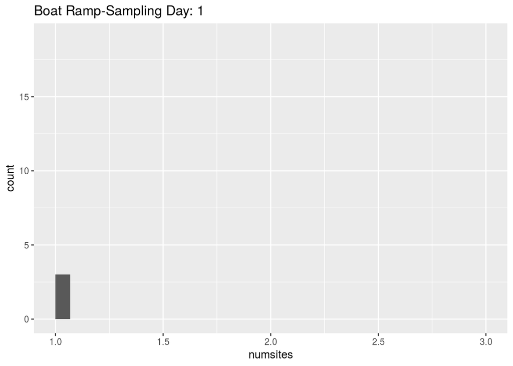

```r
dt<-rbindlist(degree_list, use.names=TRUE, fill=TRUE, idcol="SamplingDay")

p<- ggplot(dt, aes(x=numsites)) + geom_histogram(center=0)
p + transition_time(SamplingDay) +
  labs(title = "Boat Ramp-Sampling Day: {frame_time}")
```

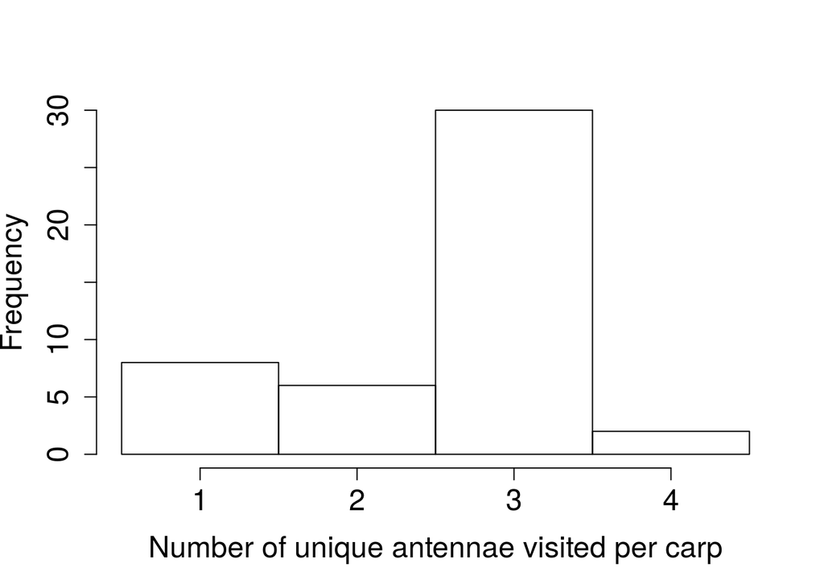

```r
#Are carp visiting all antennae at BR site (across total sampling period)?
PITs<-unique(merged_br$PIT)
carp.degree<-data.frame(PITs, numsites= rep(NA, length(PITs)))
for(i in 1:length(PITs)){
  carp.degree$numsites[i]<-length(unique(merged_br$Antenna[which(merged_br$PIT==PITs[i])]))
}

hist(carp.degree$numsites, xlab= "Number of unique antennae visited per carp", main=NULL, cex.lab=1.5, cex.axis=1.5, breaks=seq(min(carp.degree$numsites)-0.5, max(carp.degree$numsites)+0.5, by=1), right=TRUE)
```

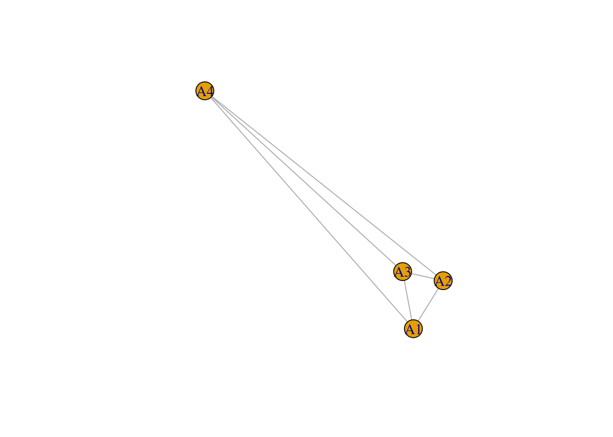

```r
#Bipartite network for boat ramp site
edgelist<-data.frame(PIT=merged_br$PIT, Reader=merged_br$Antenna)

A <- spMatrix(nrow=length(unique(edgelist$PIT)),
        ncol=length(unique(edgelist$Reader)),
        i = as.numeric(factor(edgelist$PIT)),
        j = as.numeric(factor(edgelist$Reader)),
        x = rep(1, length(as.numeric(edgelist$PIT))) )
row.names(A) <- levels(factor(edgelist$PIT))
colnames(A) <- levels(factor(edgelist$Reader))



#using carp data
bi<-graph.incidence(A, mode="all") #undirected, named graph that is bipartite
pr<-bipartite.projection(bi)
#co-membership network of nodes ($proj1), or a network of groups that share members ($proj2)

# get.adjacency(pr$proj1,sparse=FALSE,attr="weight")
plot(pr$proj2)
```

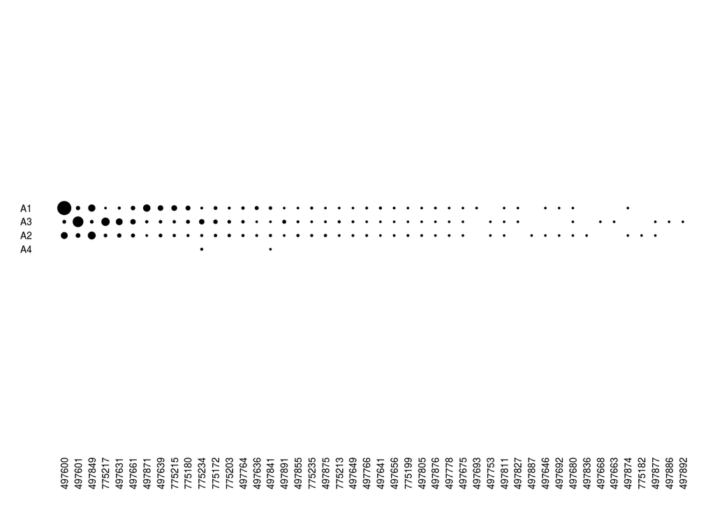

```r
visweb(t(A), circles=TRUE,  boxes=FALSE,  labsize=1, circle.max=1.5, text="no", plotsize= 18)
```

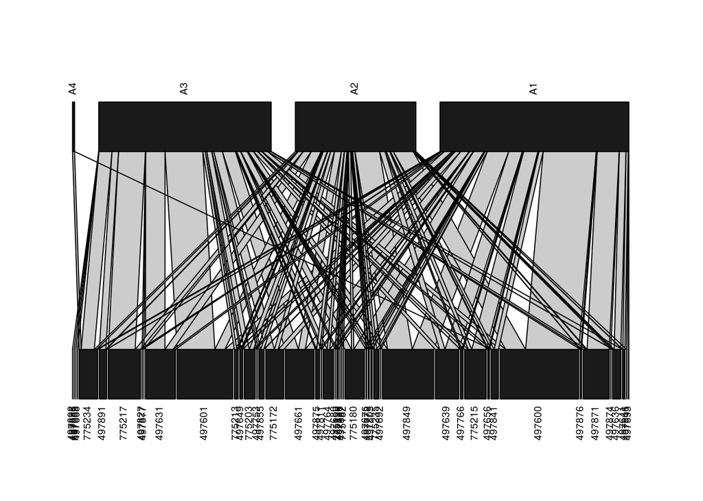

```r
plotweb(as.matrix(A), text.rot=90, labsize=1, low.lablength = 6, text.low.col="black")
```

## Crown site unique visitors and antennae usage

Identify number of unique visitors per day and whether carp are being detected by multiple antennae at given site.

- Detection numbers begin increasing on sampling day seven (start of baiting?) and peak day 11
- Most carp visit three readers, but none visit all four
- For a given sampling day, most fish are not detected by 3+ readers
- Antennae A4 is not visited at all

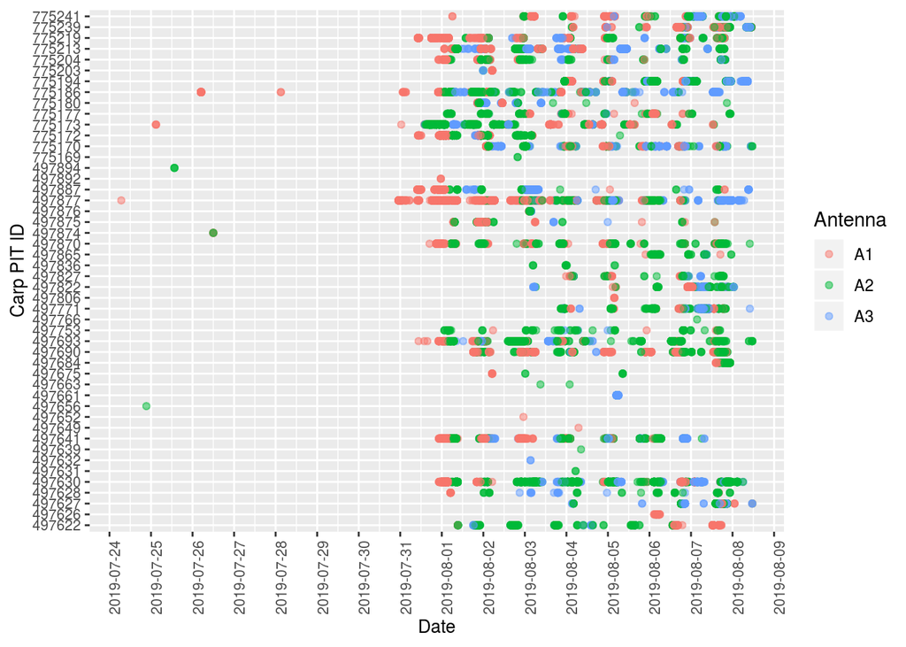

```r
ggplot(data=merged_crown, aes(DATETIME, as.factor(PIT), colour=Antenna)) +
  geom_point(alpha=0.5) +
  scale_x_datetime(date_breaks="1 day")+
  xlab("Date")+
  ylab("Carp PIT ID")+
  theme(axis.text.x=element_text(angle=90), axis.text=element_text(size=8), axis.title = element_text(size=10))
```

```r
dates<-unique(merged_crown$DATETIME) #how many dates of observation in dataset?
(min_date<-min(dates))
```

```
## [1] "2019-07-24 06:48:22 CDT"
```

```r
(max_date<-max(dates))
```

```
## [1] "2019-08-08 11:27:53 CDT"
```

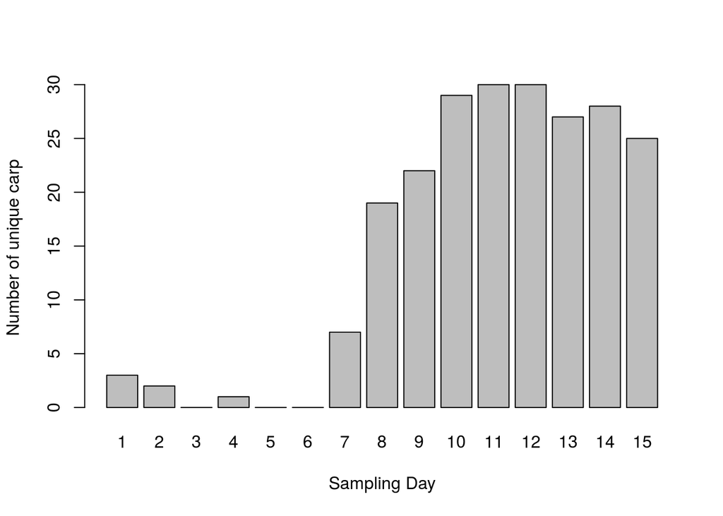

```r
start_date<-as.POSIXct("2019-07-24 12:00:00 CDT")
end_date<-as.POSIXct("2019-08-08 12:00:00 CDT")

num_days<-as.numeric(end_date-start_date)
sampling_df <-data.frame(day=1:num_days, uniqueID=rep(NA, num_days))
degree_list<-NULL

for(i in 1:num_days){
  sub_combined<-merged_crown %>% filter(DATETIME >= as.POSIXct(start_date+ (i-1)*86400, tz="CDT") & DATETIME <= as.POSIXct(start_date + i*86400, tz="CDT")) #86400 seconds/24 hours
  # print(sub_combined)
  sampling_df$uniqueID[i]<-length(unique(sub_combined$PIT))
  PITs<-unique(sub_combined$PIT)
  if(length(PITs)>0){
  carp.degree<-data.frame(PITs, numsites= rep(NA, length(PITs)))
      for(j in 1:length(PITs)){
        carp.degree$numsites[j]<-length(unique(sub_combined$Antenna[which(sub_combined$PIT==PITs[j])]))
      }
  degree_list[[i]]<-carp.degree
  }
}


sampling_df$uniqueID<-as.numeric(sampling_df$uniqueID)
barplot(uniqueID ~day, data=sampling_df, xlab="Sampling Day", ylab="Number of unique carp")
```

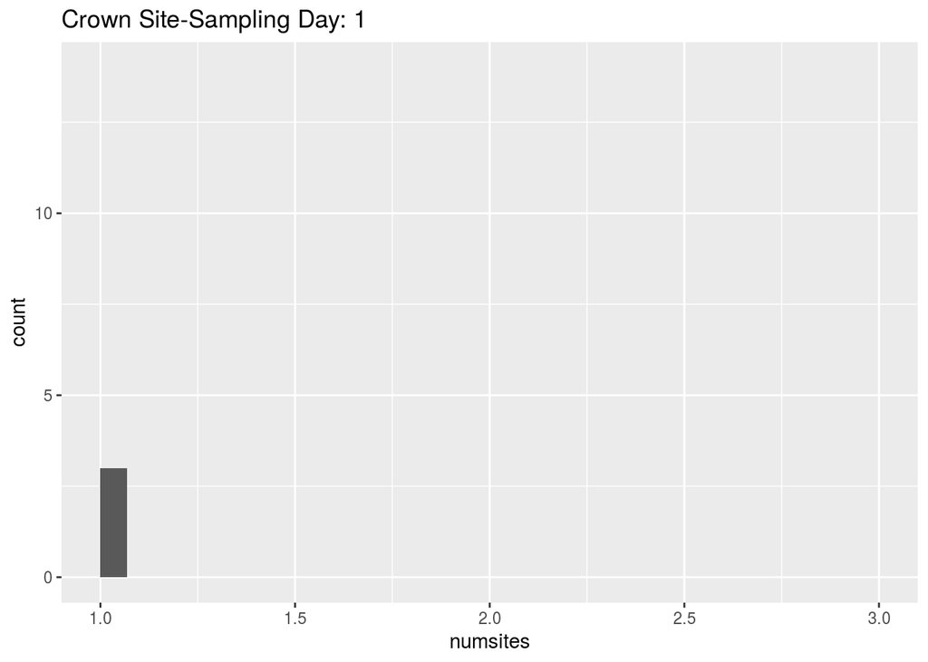

```r
dt<-rbindlist(degree_list, use.names=TRUE, fill=TRUE, idcol="SamplingDay")

p<- ggplot(dt, aes(x=numsites)) + geom_histogram()
p + transition_time(SamplingDay) +
  labs(title = "Crown Site-Sampling Day: {frame_time}")
```

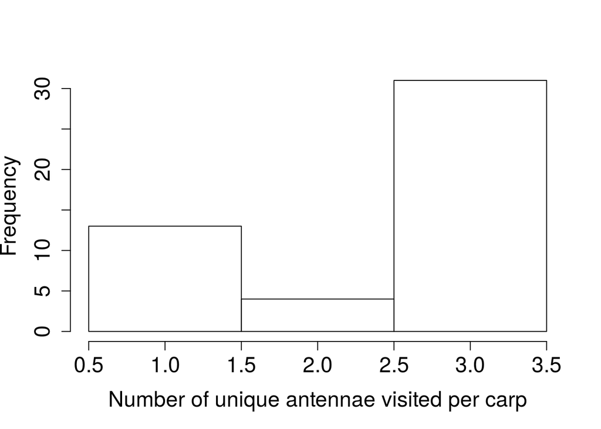

```r
#Are carp visiting all antennae?
PITs<-unique(merged_crown$PIT)
carp.degree<-data.frame(PITs, numsites= rep(NA, length(PITs)))
for(i in 1:length(PITs)){
  carp.degree$numsites[i]<-length(unique(merged_crown$Antenna[which(merged_crown$PIT==PITs[i])]))
}

hist(carp.degree$numsites, xlab= "Number of unique antennae visited per carp", main=NULL, cex.lab=1.5, cex.axis=1.5, breaks=seq(min(carp.degree$numsites)-0.5, max(carp.degree$numsites)+0.5, by=1), right=TRUE)
```

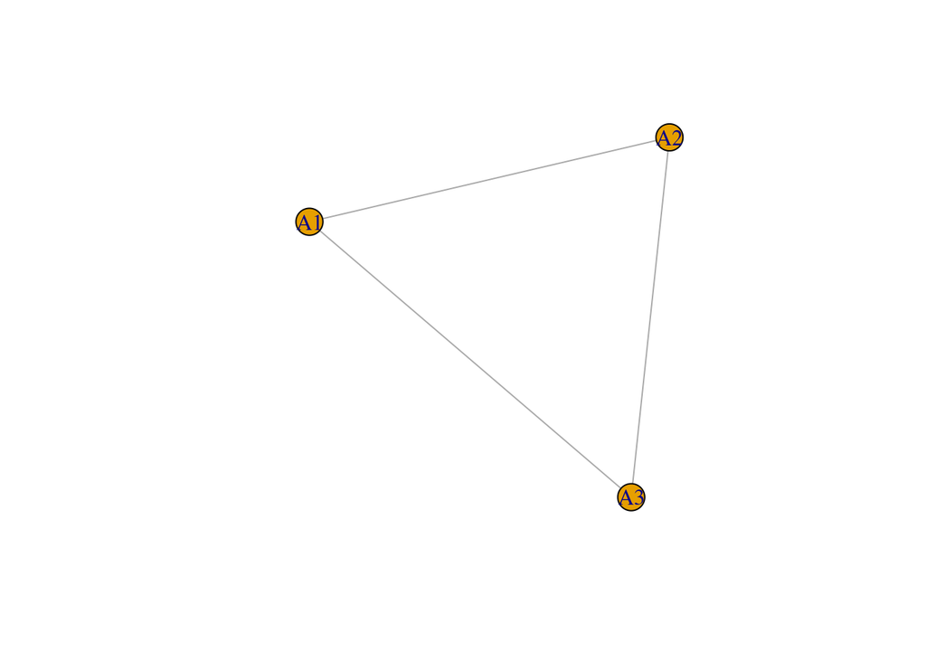

```r
#Bipartite network
edgelist<-data.frame(PIT=merged_crown$PIT, Reader=merged_crown$Antenna)
A <- spMatrix(nrow=length(unique(edgelist$PIT)),
        ncol=length(unique(edgelist$Reader)),
        i = as.numeric(factor(edgelist$PIT)),
        j = as.numeric(factor(edgelist$Reader)),
        x = rep(1, length(as.numeric(edgelist$PIT))) )
row.names(A) <- levels(factor(edgelist$PIT))
colnames(A) <- levels(factor(edgelist$Reader))

bi<-graph.incidence(A, mode="all") #undirected, named graph that is bipartite
pr<-bipartite.projection(bi)
#co-membership network of nodes ($proj1), or a network of groups that share members ($proj2)

plot(pr$proj2)
```

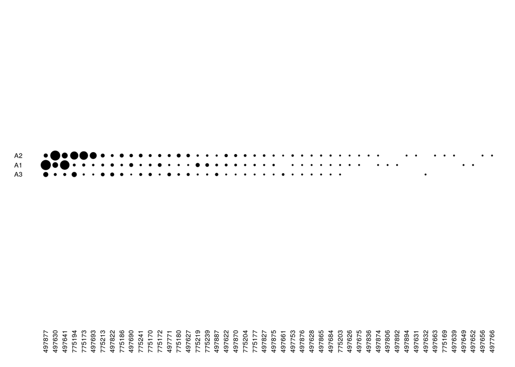

```r
visweb(t(A), circles=TRUE,  boxes=FALSE,  labsize=1, circle.max=1.5, text="no", plotsize= 18)
```

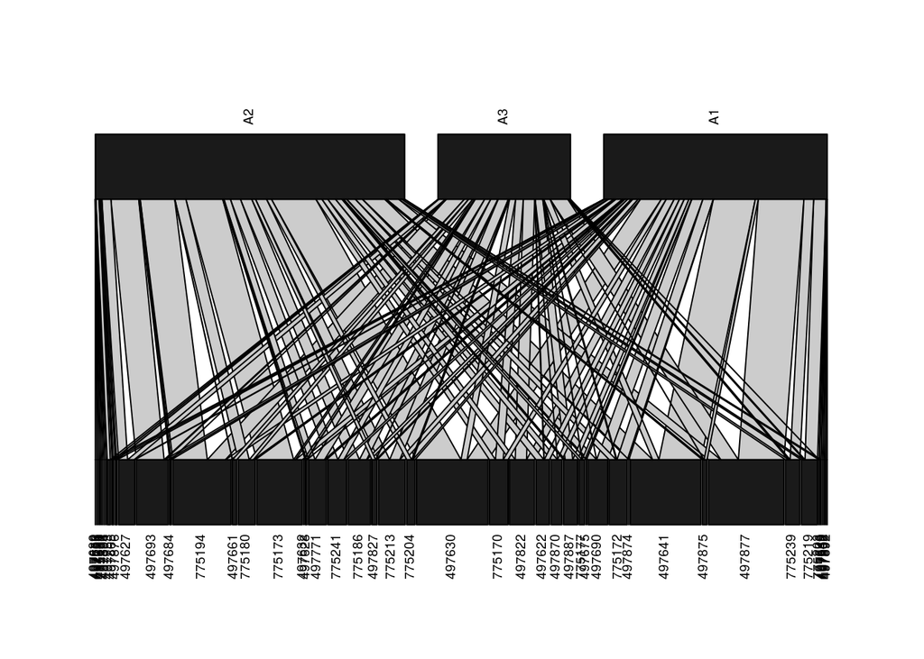

```r
plotweb(as.matrix(A), text.rot=90, labsize=1, low.lablength = 6, text.low.col="black")
```

## Lotus site unique visitors and antennae usage

- Max two unique visitors per day unbaited
- Most fish visit only one antenna; one fish visited three

```r
dates<-unique(lotus$DATETIME) #how many dates of observation in dataset?
(min_date<-min(dates))
```

```
## [1] "2019-07-30 16:28:49 CDT"
```

```r
(max_date<-max(dates))
```

```
## [1] "2019-08-04 19:30:41 CDT"
```

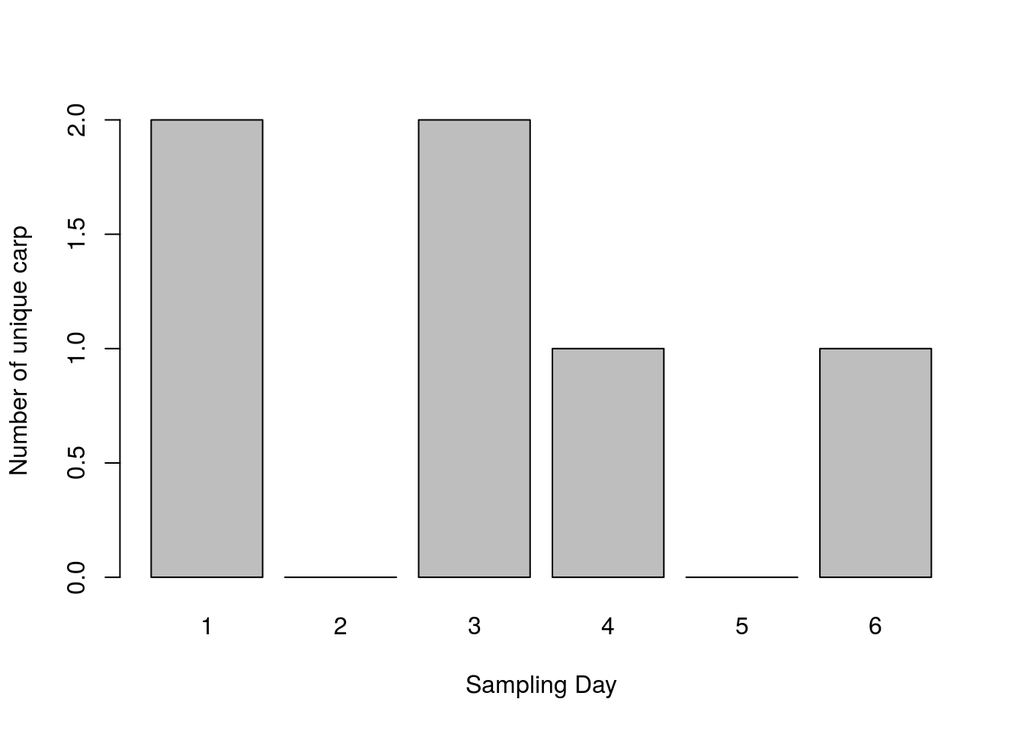

```r
start_date<-as.POSIXct("2019-07-30 12:00:00 CDT")
end_date<-as.POSIXct("2019-08-05 12:00:00 CDT")

num_days<-as.numeric(end_date-start_date)
sampling_df <-data.frame(day=1:num_days, uniqueID=rep(NA, num_days))

for(i in 1:num_days){
  sub_combined<-lotus %>% filter(DATETIME >= as.POSIXct(start_date+ (i-1)*86400, tz="CDT") & DATETIME <= as.POSIXct(start_date + i*86400, tz="CDT")) #86400 seconds/24 hours
  sampling_df$uniqueID[i]<-length(unique(sub_combined$PIT))
}

sampling_df$uniqueID<-as.numeric(sampling_df$uniqueID)
barplot(uniqueID ~day, data=sampling_df, xlab="Sampling Day", ylab="Number of unique carp")
```

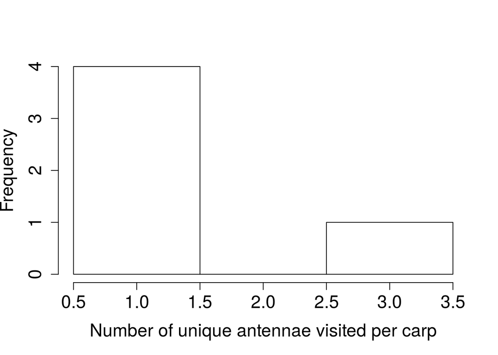

```r
#Are carp visiting all antennae?
PITs<-unique(lotus$PIT)
carp.degree<-data.frame(PITs, numsites= rep(NA, length(PITs)))
for(i in 1:length(PITs)){
  carp.degree$numsites[i]<-length(unique(lotus$Antenna[which(lotus$PIT==PITs[i])]))
}

hist(carp.degree$numsites, xlab= "Number of unique antennae visited per carp", main=NULL, cex.lab=1.5, cex.axis=1.5, breaks=seq(min(carp.degree$numsites)-0.5, max(carp.degree$numsites)+0.5, by=1), right=TRUE)
```

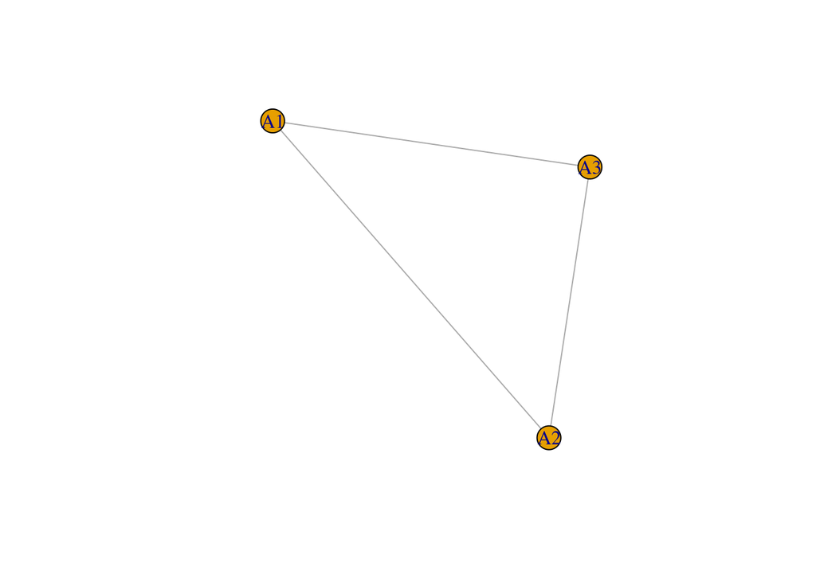

```r
#Bipartite network
edgelist<-data.frame(PIT=lotus$PIT, Reader=lotus$Antenna)
library('Matrix')
A <- spMatrix(nrow=length(unique(edgelist$PIT)),
        ncol=length(unique(edgelist$Reader)),
        i = as.numeric(factor(edgelist$PIT)),
        j = as.numeric(factor(edgelist$Reader)),
        x = rep(1, length(as.numeric(edgelist$PIT))) )
row.names(A) <- levels(factor(edgelist$PIT))
colnames(A) <- levels(factor(edgelist$Reader))

bi<-graph.incidence(A, mode="all") #undirected, named graph that is bipartite
pr<-bipartite.projection(bi)
#co-membership network of nodes ($proj1), or a network of groups that share members ($proj2)

plot(pr$proj2)
```

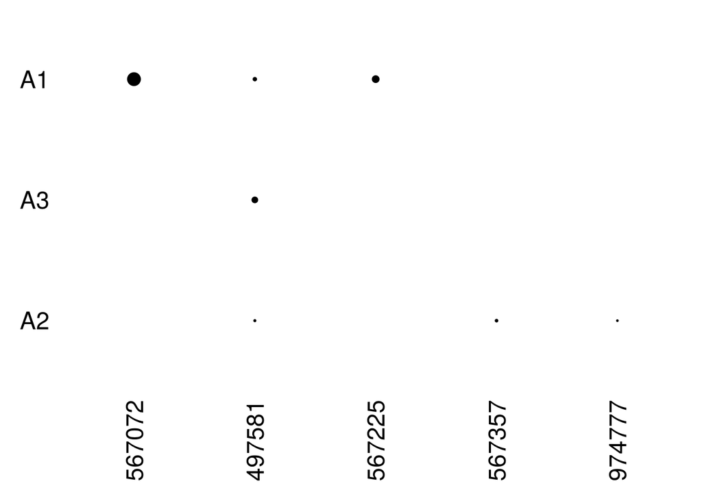

```r
visweb(t(A), circles=TRUE,  boxes=FALSE,  labsize=1, circle.max=1.5, text="no", plotsize= 5)
```

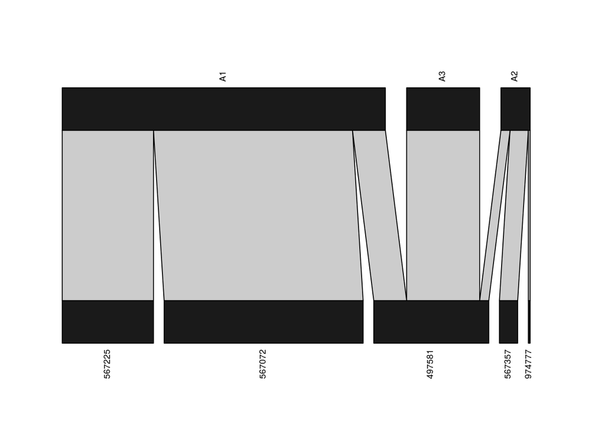

```r
plotweb(as.matrix(A), text.rot=90, labsize=1, low.lablength = 6, text.low.col="black")
```

## Are fish visiting multiple sites?

- Some fish are visiting both BR and C

```r
#Combine observations across sites
combined_sites <- rbind(merged_br, merged_crown)
head(combined_sites)
```

[output not shown]

```r
#Bipartite network for boat ramp site
edgelist<-data.frame(PIT=combined_sites$PIT, Reader=combined_sites$Site)
library('Matrix')
A <- spMatrix(nrow=length(unique(edgelist$PIT)),
        ncol=length(unique(edgelist$Reader)),
        i = as.numeric(factor(edgelist$PIT)),
        j = as.numeric(factor(edgelist$Reader)),
        x = rep(1, length(as.numeric(edgelist$PIT))) )
row.names(A) <- levels(factor(edgelist$PIT))
colnames(A) <- levels(factor(edgelist$Reader))

library('igraph')

#using carp data
bi<-graph.incidence(A, mode="all") #undirected, named graph that is bipartite
pr<-bipartite.projection(bi)
#co-membership network of nodes ($proj1), or a network of groups that share members ($proj2)
pr$proj2
```

```
## IGRAPH 6d453c9 UNW- 2 1 --
## + attr: name (v/c), weight (e/n)
## + edge from 6d453c9 (vertex names):
## [1] B--C
```

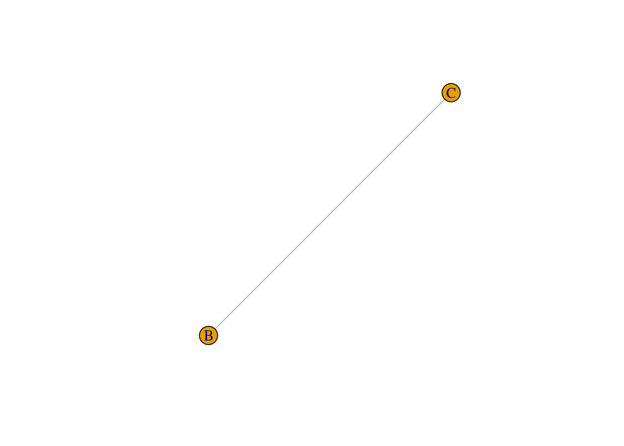

```r
# get.adjacency(pr$proj1,sparse=FALSE,attr="weight")
plot(pr$proj2)
```

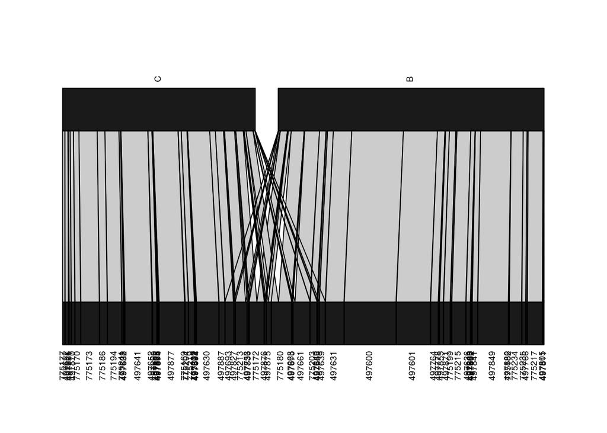

```r
# install.packages('bipartite')
library('bipartite')
# visweb(t(A), prednames=TRUE, preynames=TRUE, labsize = 1)
# visweb(t(A), circles=TRUE,  boxes=FALSE,  labsize=1, circle.max=1.5, text="no", plotsize= 15)
plotweb(as.matrix(A), text.rot=90, labsize=1, low.lablength = 6, text.low.col="black")
```

```r
unique(lotus$PIT[which(lotus$PIT %in% boatramp2$PIT)])
```

```
## [1] "497581"
```

```r
unique(lotus$PIT[which(lotus$PIT %in% crown$PIT)])
```

```
## [1] "497581"
```

```r
unique(crown$PIT[which(crown$PIT %in% boatramp2$PIT)])
```

```
##  [1] "497656" "567150" "567207" "497581" "497887" "775172" "497693"
##  [8] "038301" "038339" "775213" "497753" "497875" "038391" "775180"
## [15] "775203" "497675" "497876" "497836" "497663" "038387" "497827"
## [22] "497631" "497649" "497639" "038369" "038344" "038361" "497661"
```

```r
"497581" %in% pit_capture$PIT
```

```
## [1] FALSE
```